# Point de changement : Full et Cut

# 1.

J’ai écrit la moyenne comme ceci :

$$\text{avant }k :\ \theta_1,
\qquad
\text{après }k :\ \theta_1+\theta_2.$$

$\theta_2$ est donc le changement de moyenne. J’ai conservé le modèle a priori initial en transformant aussi le prior des paramètres.

J’ai utilisé **un seul jeu de données de 120 observations** : la moyenne passe de 2 à 6 après l’observation 60. L’écart-type du bruit est 1,2.

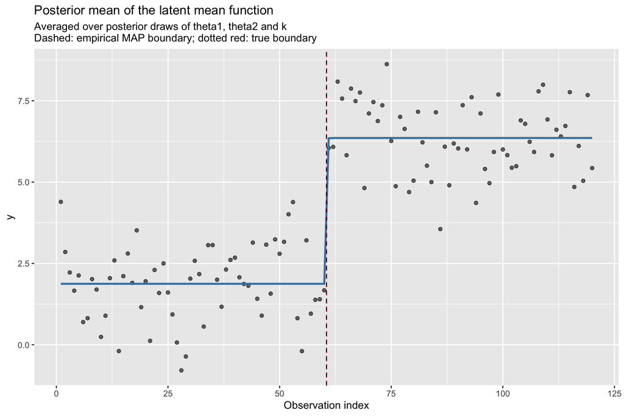

Les points sont les données. La ligne bleue est la moyenne estimée avec la première chaîne. Elle tient compte de l’incertitude sur les paramètres et sur $k$.

# 2. Full : j’estime aussi le point de changement

J’ai lancé **quatre chaînes sur les mêmes données**, en commençant à $k=20,40,80,100$. Pour chaque chaîne, j’ai gardé 5 000 tirages après avoir supprimé les 1 000 premières itérations.

Les quatre chaînes donnent **60 comme valeur la plus probable de $k$**. Avec leurs tirages réunis, la probabilité estimée de $k=60$ est **99,78 %**.

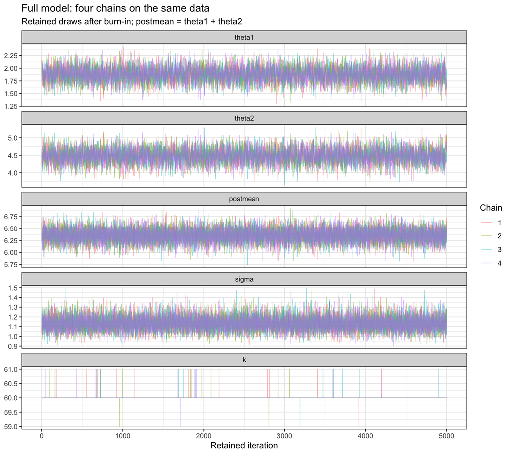

Chaque couleur est une chaîne. Elles donnent des résultats proches. Les diagnostics sont favorables et l’erreur Monte Carlo est petite.

| Paramètre | R-hat | ESS | Erreur MC de la moyenne |
| --- | --- | --- | --- |
| theta1 | 1.00058 | 6402 | 0.00181 |
| theta2 | 1.00096 | 6253 | 0.00260 |
| postmean | 1.00028 | 20096 | 0.00103 |
| sigma | 1.00003 | 19215 | 0.00054 |

# 3. Full : je fixe ensuite le point de changement

J’ai refait Full avec **$k=60$ fixé**, sans changer les données ni les priors. Cela me donne une référence où la vraie frontière est connue.

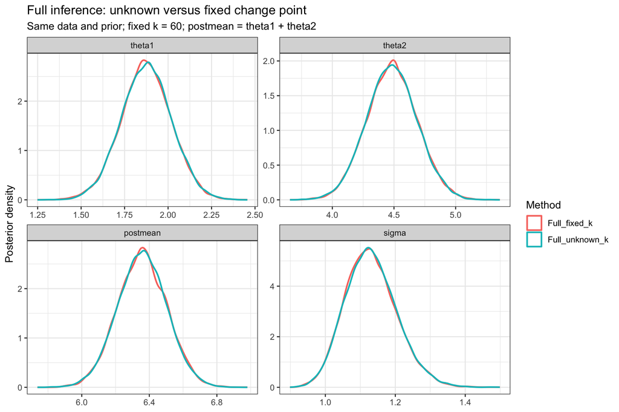

Les deux courbes sont presque identiques : rouge pour $k$ fixé, turquoise pour $k$ inconnu. C’est cohérent avec la forte probabilité déjà obtenue pour $k=60$.

# 4. Cut : je bloque le retour d’information

J’ai gardé **$k=60$** pour comparer Full et Cut à la même frontière.

Dans Cut, j’apprends $\theta_1$ et $\sigma$ avec le premier segment seulement. Ensuite, j’utilise leurs tirages pour apprendre $\theta_2$ avec le deuxième segment. Je transmets donc leur incertitude, sans retour du deuxième segment vers le premier.

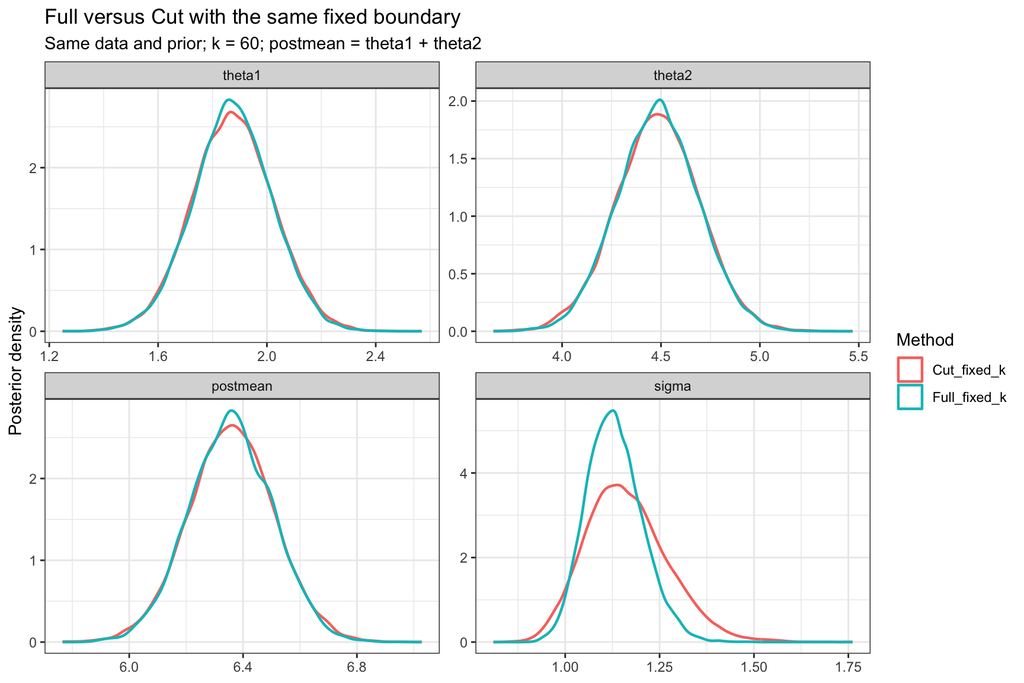

Ici, **rouge = Cut** et **turquoise = Full**. Les moyennes sont très proches. La différence principale concerne $\sigma$ : sa distribution est plus large avec Cut.

| Méthode | Moyenne de sigma | Écart-type du posterior de sigma |
| --- | --- | --- |
| Full | 1.131 | 0.074 |
| Cut | 1.164 | 0.109 |